# hw2

cayden dunn

2022-10-27

#get data

```r
b_housing <- read.csv("/Users/cindydunn/Desktop/Grad_School/math540/hw2/data/BostonHousing.csv")

b_housing$CAT..MEDV <- as.factor(b_housing$CAT..MEDV) # factor with 2 levels
levels(b_housing$CAT..MEDV) <- c("no", "yes") # redefine levels

## Include the functions required for data partitioning
source("/Users/cindydunn/Desktop/Grad_School/math540/hw2/myfunctions copy.r")
#remove MEDV from the data set
b_housing <- b_housing[,-13]
```

# A. Split the data into training (80%) and test (20%) datasets.

# Create training validation test data

```r
RNGkind (sample.kind = "Rounding")
set.seed(123) ## set seed so that you get same partition each time
p2 <- partition.2(b_housing, 0.8) ## creating 80:20 partition
training.data <- p2$data.train # training data
test.data <- p2$data.test # test data
```

#1. Build a k-nearest neighbor model. Clearly show the model building steps for full credit. What is the optimal number of neighbors?

1 is the best k

```r
### Rescale the data
#center is the mean of each column
#scale is the standard deviation of each column
# the -9 drops that coulmn from the dataframe
training.scaled <- scale(training.data[,-13], center = TRUE, scale = TRUE) # exclude the response vairable from the data set for scaling
training.scaled.wY <- cbind(training.scaled, training.data[,13])
training.scaled.attr <- attributes(training.scaled)
test.scaled <- scale(test.data[,-13],
                    center = training.scaled.attr$`scaled:center`,
                    scale = training.scaled.attr$`scaled:scale`)

library(FNN)
library(caret)
### fit k-nn model for k = 1, ..., 100
K <- 100
kappa <- rep(0, K)
for (kk in 1:K){
  Knn <- knn(train = training.scaled, test = test.scaled,
             cl = training.data[,13], k = kk)
  c <- confusionMatrix(as.factor(Knn), as.factor(test.data[,13]),
                       positive = "yes")
  kappa[kk] <- c$overall["Kappa"]
  #cat("K", kk, "Kappa", kappa[kk], "\n")
}
```

[output not shown]

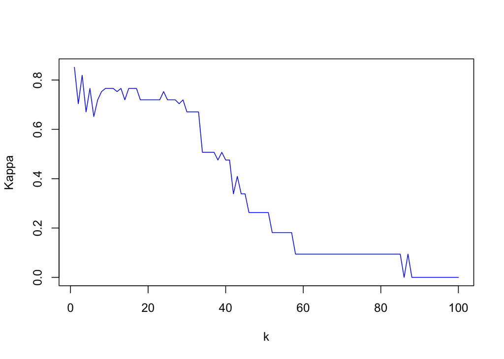

```r
# create a plot for k vs. kappa
plot(c(1:K), kappa, xlab = "k", ylab = "Kappa", type = "l", col = "blue")
```

```r
which.max((kappa)) # the best k
```

```
## [1] 1
```

```r
# we are looking for the largest kappa value
```

# 2. Evaluate the predictive performance of this model on the test data.

Prediction no yes no 83 3 yes 1 14

Accuracy : 0.9604 Sensitivity : 0.8235 Specificity : 0.9881

```r
### fit k-nn model on test data with k=1
Knn <- knn(train = training.scaled, test = test.scaled,
           cl = training.data[,13], k = 1)
confusionMatrix(as.factor(Knn), as.factor(test.data[,13]),
                positive = "yes")
```

```
## Confusion Matrix and Statistics
##
##           Reference
## Prediction no yes
##        no  83   3
##        yes  1  14
##
##                Accuracy : 0.9604
##                  95% CI : (0.9017, 0.9891)
##     No Information Rate : 0.8317
##     P-Value [Acc > NIR] : 6.967e-05
##
##                   Kappa : 0.8516
##
##  Mcnemar's Test P-Value : 0.6171
##
##             Sensitivity : 0.8235
##             Specificity : 0.9881
##          Pos Pred Value : 0.9333
##          Neg Pred Value : 0.9651
##              Prevalence : 0.1683
##          Detection Rate : 0.1386
##    Detection Prevalence : 0.1485
##       Balanced Accuracy : 0.9058
##
##        'Positive' Class : yes
##
```

# B. Use the BostonHousing data to accomplish the following modeling tasks.

#gonna rest the data just to make sure nothing gets messed up

```r
b_housing <- read.csv("/Users/cindydunn/Desktop/Grad_School/math540/hw2/data/BostonHousing.csv")

b_housing$CAT..MEDV <- as.factor(b_housing$CAT..MEDV) # factor with 2 levels
levels(b_housing$CAT..MEDV) <- c("no", "yes") # redefine levels

#remove MEDV from the data set
b_housing <- b_housing[,-13]

# A. Split the data into training (80%) and test (20%) datasets.
# Create training validation test data
RNGkind (sample.kind = "Rounding")
set.seed(123) ## set seed so that you get same partition each time
p2 <- partition.2(b_housing, 0.8) ## creating 80:20 partition
training.data <- p2$data.train # training data
test.data <- p2$data.test # test data
```

```r
library(rpart)
library(rpart.plot)
# fit classification tree on training data
# minsplit refers to the minimum number of observations that must exist
# in a node in order for a split to be attempted. The default value is 20.
# minbucket argument can be specified to indicate the minimum number of
# required observations in the terminal nodes for the split to happen.
ct1 <- rpart(CAT..MEDV ~ . , data = training.data, method = "class",
             minsplit=15, minbucket = 5)
#minsplit - minimum number of observations in a node for a split to be attempted
#minbucket - minimum number of observations in a terminal node for a split to to be valid
# Ex. if u split a node with 16 observations, and get 2 terminal nodes with 13 observations and 3 then the split is not valid as 3 is less than minbucket,
```

# plot tree

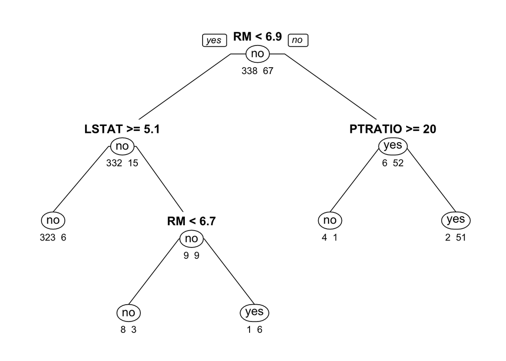

```r
prp(ct1, type = 1, extra = 1, under = TRUE, split.font = 2, varlen = -10)
```

# variable importance

```r
ct1$variable.importance
```

```
##         RM      LSTAT    PTRATIO         ZN       CRIM        TAX        RAD
## 75.2923860 30.7992055 16.9568792  7.4865836  6.3529668  5.0825307  4.2476513
##      INDUS        NOX        DIS        AGE
##  3.7432918  3.1857385  2.1238256  0.8348794
```

#2. Write down the results in terms of rules. (i.e. for each terminal node, write down the decision and list the conditions that must be followed to reach that decision)

```r
summary(ct1)
```

```
## Call:
## rpart(formula = CAT..MEDV ~ ., data = training.data, method = "class",
##     minsplit = 15, minbucket = 5)
##   n= 405
##
##           CP nsplit rel error    xerror       xstd
## 1 0.68656716      0 1.0000000 1.0000000 0.11160751
## 2 0.04477612      1 0.3134328 0.3582090 0.07091952
## 3 0.03731343      2 0.2686567 0.3432836 0.06951736
## 4 0.01000000      4 0.1940299 0.3134328 0.06659980
##
## Variable importance
##      RM   LSTAT PTRATIO      ZN    CRIM     TAX     RAD   INDUS     NOX     DIS
##      48      20      11       5       4       3       3       2       2       1
##     AGE
##       1
##
## Node number 1: 405 observations,    complexity param=0.6865672
##   predicted class=no   expected loss=0.1654321  P(node) =1
##     class counts:   338    67
##    probabilities: 0.835 0.165
##   left son=2 (347 obs) right son=3 (58 obs)
##   Primary splits:
##       RM      < 6.941    to the left,  improve=72.37031, (0 missing)
##       LSTAT   < 5.145    to the right, improve=50.87841, (0 missing)
##       INDUS   < 3.985    to the right, improve=32.66483, (0 missing)
##       PTRATIO < 18.35    to the right, improve=18.26238, (0 missing)
##       TAX     < 267.5    to the right, improve=18.01003, (0 missing)
##   Surrogate splits:
##       LSTAT   < 4.265    to the right, agree=0.901, adj=0.310, (0 split)
##       PTRATIO < 14.15    to the right, agree=0.879, adj=0.155, (0 split)
##       ZN      < 87.5     to the left,  agree=0.872, adj=0.103, (0 split)
##       INDUS   < 1.605    to the right, agree=0.864, adj=0.052, (0 split)
##       CRIM    < 0.013355 to the right, agree=0.859, adj=0.017, (0 split)
##
## Node number 2: 347 observations,    complexity param=0.03731343
##   predicted class=no   expected loss=0.04322767  P(node) =0.8567901
##     class counts:   332    15
##    probabilities: 0.957 0.043
##   left son=4 (329 obs) right son=5 (18 obs)
```

[output cut: 54 more lines]

```
##
## Node number 7: 53 observations
##   predicted class=yes  expected loss=0.03773585  P(node) =0.1308642
##     class counts:     2    51
##    probabilities: 0.038 0.962
##
## Node number 10: 11 observations
##   predicted class=no   expected loss=0.2727273  P(node) =0.02716049
##     class counts:     8     3
##    probabilities: 0.727 0.273
##
## Node number 11: 7 observations
##   predicted class=yes  expected loss=0.1428571  P(node) =0.01728395
##     class counts:     1     6
##    probabilities: 0.143 0.857
```

When creating a decsion tree there are two conditions that dictate how terminal nodes are created and these two paramters are minsplit and minbucket. These terms are defined below and the values passed for this decesion tree are minsplit=15, minbucket = 5. minsplit - minimum number of observations in a node for a split to be attempted minbucket - minimum number of observations in a terminal node for a split to to be valid

1. root 405 67 no (0.83456790 0.16543210)
2. RM< 6.941 347 15 no (0.95677233 0.04322767)  
   4) LSTAT>=5.055 329 6 no (0.98176292 0.01823708) * 329 observations this passes the minsplit constraint this must have failed min bucket when this node was attempted to be split 5) LSTAT< 5.055 18 9 no (0.50000000 0.50000000)
   10. RM< 6.687 11 3 no (0.72727273 0.27272727) * 11 observations in this node fails minsplit constraint so it cannot be split any further
   11. RM>=6.687 7 1 yes (0.14285714 0.85714286) * 7 observations in this node fails minsplit constraint so it cannot be split any further
3. RM>=6.941 58 6 yes (0.10344828 0.89655172) 6) PTRATIO>=19.65 5 1 no (0.80000000 0.20000000) * 5 observations in this node fails minsplit constraint so it cannot be split any further 7) PTRATIO< 19.65 53 2 yes (0.03773585 0.96226415) * 53 observations this passes the minsplit constraint this must have failed min bucket when this node was attemped to be split

# check to see how the model preformed

```r
pred.test = predict(ct1, test.data, type = 'class')

# create confusion matrix
library(caret)
confusionMatrix(pred.test, test.data$CAT..MEDV, positive = "yes")
```

```
## Confusion Matrix and Statistics
##
##           Reference
## Prediction no yes
##        no  80   2
##        yes  4  15
##
##                Accuracy : 0.9406
##                  95% CI : (0.8752, 0.9779)
##     No Information Rate : 0.8317
##     P-Value [Acc > NIR] : 0.001008
##
##                   Kappa : 0.7973
##
##  Mcnemar's Test P-Value : 0.683091
##
##             Sensitivity : 0.8824
##             Specificity : 0.9524
##          Pos Pred Value : 0.7895
##          Neg Pred Value : 0.9756
##              Prevalence : 0.1683
##          Detection Rate : 0.1485
##    Detection Prevalence : 0.1881
##       Balanced Accuracy : 0.9174
##
##        'Positive' Class : yes
##
```

Prediction no yes no 80 2 yes 4 15

Accuracy : 0.9406 Sensitivity : 0.8824  
Specificity : 0.9524 Kappa : 0.7973

The model preforms well

# C. Compare the performances of the two models that you built in this assignment.

Model 1’s performance

Prediction no yes no 83 3 yes 1 14

Accuracy : 0.9604 Sensitivity : 0.8235 Specificity : 0.9881 Kappa : 0.8516

model 2’s preformance

Prediction no yes no 80 2 yes 4 15

Accuracy : 0.9406 Sensitivity : 0.8824  
Specificity : 0.9524 Kappa : 0.7973